# Data Visualization - Mini-Project 1

Michael Wakefield `mwakefield1326@floridapoly.edu`

# Mini-Project 1 - Finishers of the Boston Marathon of 2017

## Introduction

This project explores data of the finishers of the 2017 Boston Marathon. The main objective is to analyze the participant demographics and investigate how age and gender relate to marathon performance. Three visualizations are used to explore age distribution, finish times, and runner pace.

## Load Dataset

```r
marathon <- read_csv(
  "../data/marathon_results_2017.csv",
  na = c("", "-", "NA"),
  col_types = cols(
    Name = col_character(),
    Age = col_double(),
    `M/F` = col_character(),
    `Official Time` = col_character(),
    Pace = col_character()
  )
)
```

## Clean Dataset

```r
marathon_clean <- marathon %>%
  select(Name, Age, `M/F`, `Official Time`, Pace) %>%
  drop_na()
```

Convert the time columns into minutes

```r
time_to_minutes <- function(x) {
  sapply(strsplit(x, ":"), function(parts) {
    parts <- as.numeric(parts)

    if (length(parts) == 3) {
      parts[1] * 60 + parts[2] + parts[3] / 60
    } else if (length(parts) == 2) {
      parts[1] + parts[2] / 60
    } else {
      NA
    }
  })
}

marathon_clean <- marathon_clean %>%
  mutate(
    total_minutes = time_to_minutes(`Official Time`),
    pace_min = time_to_minutes(Pace)
  )
```

# Visulaization 1

## Runner’s Age Distribution

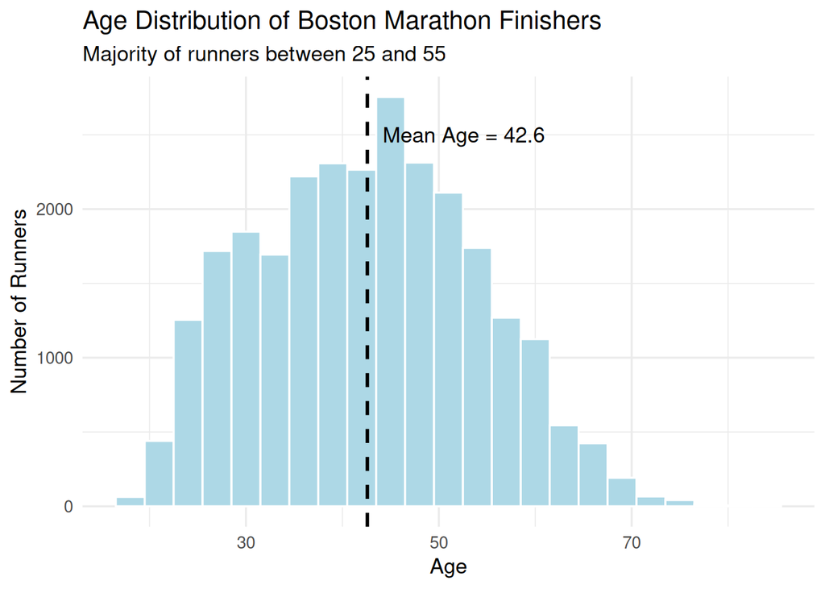

```r
mean_age <- mean(marathon_clean$Age)

ggplot(marathon_clean, aes(x = Age)) +
  geom_histogram(
    binwidth = 3,
    fill = "lightblue",
    color = "white"
  ) +
  geom_vline(
    xintercept = mean_age,
    linetype = "dashed",
    linewidth = 1
  ) +
  annotate(
    "text",
    x = mean_age + 10,
    y = 2500,
    label = paste("Mean Age =", round(mean_age,1))
  ) +
  labs(
    title = "Age Distribution of Boston Marathon Finishers",
    subtitle = "Majority of runners between 25 and 55",
    x = "Age",
    y = "Number of Runners"
  )
```

```r
ggsave(
  filename = paste0(fig_path, "project1_vis1_age_distribution.png"),
  width = 7,
  height = 5,
  dpi = 300
)
```

###Analysis: The age distribution shows that most of the runners are between ages **25** and **55**. From this data, it can be seen that running is mainly popular with runners that can balance physical abilities and discipline needed for long runs and training. Younger runners tend to less endurance training, while other runners tend to have more limitations. However, it can be seen that there are runners over 60, which prove that running marathons across a wide range of ages.

# Visualization 2

## Average Finish Time by Gender and Age Group

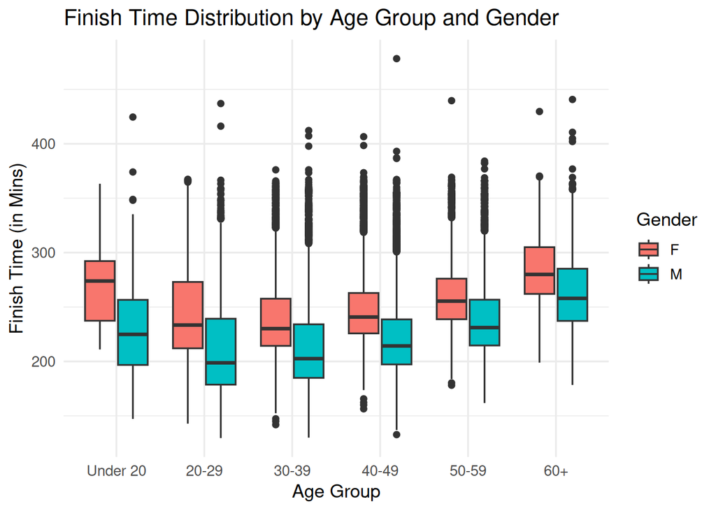

```r
finish_time_plot <- marathon_clean %>%
  mutate(
    age_group = case_when(
      Age < 20 ~ "Under 20",
      Age < 30 ~ "20-29",
      Age < 40 ~ "30-39",
      Age < 50 ~ "40-49",
      Age < 60 ~ "50-59",
      TRUE ~ "60+"
    )
  )

finish_time_plot$age_group <- factor(
  finish_time_plot$age_group,
  levels = c("Under 20","20-29","30-39","40-49","50-59","60+")
)

ggplot(
  finish_time_plot,
  aes(x = age_group, y = total_minutes, fill = `M/F`)
) +
  geom_boxplot() +
  labs(
    title = "Finish Time Distribution by Age Group and Gender",
    x = "Age Group",
    y = "Finish Time (in Mins)",
    fill = "Gender"
  )
```

```r
ggsave(
  filename = paste0(fig_path, "project1_vis2_finish_time_boxplot.png"),
  width = 7,
  height = 5,
  dpi = 300
)
```

# Visualization 3

## Runner Pace Distribution by Age Group

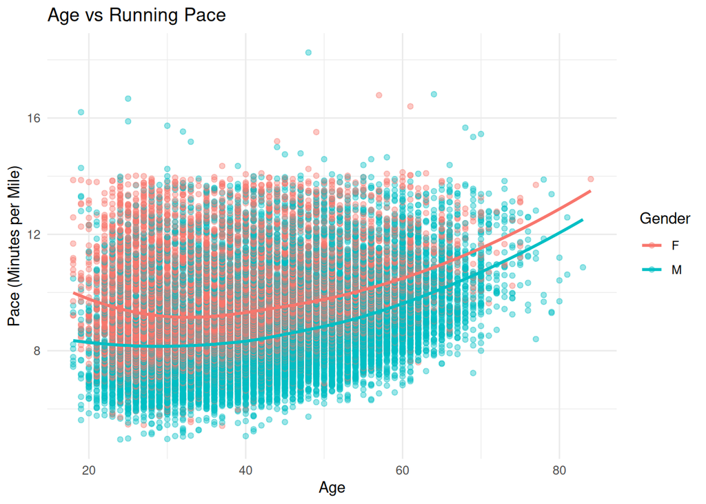

```r
ggplot(marathon_clean, aes(x = Age, y = pace_min, color = `M/F`)) +
  geom_point(alpha = 0.4) +
  geom_smooth(method = "loess", se = FALSE) +
  labs(
    title = "Age vs Running Pace",
    x = "Age",
    y = "Pace (Minutes per Mile)",
    color = "Gender"
  ) +
  theme_minimal()
```

```r
ggsave(
  filename = paste0(fig_path, "project1_vis3_age_vs_pace.png"),
  width = 7,
  height = 5,
  dpi = 300
)
```

# Report

#### What story could you tell with your plots?

All three plots really tell a story about how marathon participants and performance vary across different demographics. From the very first data visualization, age distributions show that age does not really stop anyone from running. Some runners are older than 70 years old, but most runners tend to fall between 25 and 55 years old. This shows that running marathons is more popular among adults in their prime years. However, there were still runners under 20 and over 60 years old, but there was a clear concentration in the middle-aged groups.

The performance visualizations really showed me that age and gender both have an impact on marathon results. Younger runners tend to have faster finish times and better pace. The average performance tended to decline as the runners got older. These charts also showed that male runners generally had faster average finish times than female runners across most of the age groups. Overall, these visualizations really show the key demographic trends and how characteristics can really relate to performance.

#### How did you apply the principles of data visualizations and design for this assignment?

I applied the data visualization principles by selecting three different chart types that really matched the data and the point that was being explored. Each chart has clear tiles, axis labels, and consistent formatting to have clear readability and interpretation. Each visualization was created to be simple and uncluttered and created in a sense that anyone can quickly identify patterns, compare groups, and understand the data that is being collected.